# Example pathway analysis

In this notebook, I will perform a pathway analysis on example data. This data set was obtained from an analysis using the $\texttt{DESeq2}$ package performed on the following mouse data: https://github.com/carpentries-incubator/bioc-rnaseq/tree/main/episodes/data

The pathway analysis relies on the following functions from the $\texttt{functions.R}$ file:

- $\texttt{find_min_alpha}$, which calculates $\alpha_{min}$ for a given pathway.
- $\texttt{test_result}$, a helper function to determine whether a given pathway is valid at level $\alpha$.

The data sets that I used for the analyses in my thesis looked similar to the output below. Note the $\texttt{gene_id}$ column, which consists of Ensembl gene IDs.

```r
source("functions.R")
df <- read.csv("example_data.csv")
head(df)
```

|  | gene_id | baseMean | log2FoldChange | lfcSE | stat | pvalue | padj |
| --- | --- | --- | --- | --- | --- | --- | --- |
| 1 | ENSMUSG00000051951 | 1937.755565 | -0.23572950 | 0.10821410 | -2.17836209 | 0.029379090 | 0.083975110 |
| 2 | ENSMUSG00000025900 | 2.273456 | -0.25918136 | 0.68286636 | -0.37954917 | 0.704280102 | 0.825911735 |
| 3 | ENSMUSG00000025902 | 251.005963 | -0.31972830 | 0.08306290 | -3.84923111 | 0.000118489 | 0.000791362 |
| 4 | ENSMUSG00000102269 | 2.856054 | 0.04614185 | 0.63513575 | 0.07264879 | 0.942085598 | 0.968662021 |
| 5 | ENSMUSG00000103922 | 6.285971 | -0.77944618 | 0.40090072 | -1.94423741 | 0.051866828 | 0.132210645 |
| 6 | ENSMUSG00000033845 | 1134.810992 | -0.08239502 | 0.05874037 | -1.40269833 | 0.160706815 | 0.311360501 |

First, we obtain the GO terms from the $\texttt{org.Mm.eg.db}$ library, which is available on Bioconductor.

```r
library(org.Mm.eg.db)

gobimap <- toTable(org.Mm.egGO)
GOIDs   <- unique(gobimap$go_id)
GOList  <- lapply(GOIDs, function(id) gobimap$gene_id[gobimap$go_id == id])

# Make sure the IDs are unique and the paths are non-empty
GOList <- lapply(GOList, unique)
GOList <- lapply(GOList, function(path) if (all(is.na(path))) character(0) else path)

GOList[[2]]
```

```
[1] "11298" "67877" "72117" "74763"
```

As seen from the output above, the GO terms use a different identifier to encode the genes. To map these to the Ensembl format, we use several functions from the $\texttt{biomaRt}$ library, which is also available on Bioconductor. Note that a warning may appear which says that the ‘Ensembl site is unresponsive’, but this can safely be ignored.

```r
library(biomaRt)

ensembl <- useEnsembl("genes", dataset = "mmusculus_gene_ensembl")
BM      <- getBM(attributes = c("ensembl_gene_id", "entrezgene_id"),
                 filters = "ensembl_gene_id", values = df$gene_id, mart = ensembl)
map     <- split(BM$ensembl_gene_id, BM$entrezgene_id)

map_pathway <- function(path) {
  path     <- unique(as.character(path))
  new_path <- unlist(map[path], use.names = FALSE)

  if (length(new_path) == 0) {
    return(character(0))
  }

  return(new_path)
}

ensemblList <- lapply(GOList, map_pathway)
ensemblList[[2]]
```

```
[1] "ENSMUSG00000020804" "ENSMUSG00000002728" "ENSMUSG00000022698" "ENSMUSG00000005982"
```

The identifiers of the GO terms now correspond to the Ensembl IDs in the example data set. To fetch the KEGG pathways and perform a similar conversion, we use the $\texttt{enrichKEGG}$ function from the $\texttt{clusterProfiler}$ library. Again, this package is available on Bioconductor.

Using this function to fetch KEGG pathways is relatively uncommon, but it has the advantage of providing (most) of the names for each KEGG pathway. Note that a warning may appear which says that there is an ‘SSL connect error’, but this warning can also safely be ignored.

```r
library(clusterProfiler)

entrez <- keys(org.Mm.eg.db, keytype = "ENTREZID")

ek <- enrichKEGG(
  gene = entrez,
  organism = "mmu",
  keyType = "kegg"
)

KEGGList <- lapply(ek@geneSets, map_pathway)
KEGGList$mmu00020
```

```
 [1] "ENSMUSG00000020917" "ENSMUSG00000028405" "ENSMUSG00000022477" "ENSMUSG00000005683" "ENSMUSG00000020664"
 [6] "ENSMUSG00000026526" "ENSMUSG00000025950" "ENSMUSG00000002010" "ENSMUSG00000027406" "ENSMUSG00000019179"
[11] "ENSMUSG00000020321" "ENSMUSG00000020456" "ENSMUSG00000027513" "ENSMUSG00000024892" "ENSMUSG00000031299"
[16] "ENSMUSG00000022110" "ENSMUSG00000061838" "ENSMUSG00000000168" "ENSMUSG00000021913" "ENSMUSG00000084234"
[21] "ENSMUSG00000030541" "ENSMUSG00000052738" "ENSMUSG00000058076" "ENSMUSG00000000171" "ENSMUSG00000021577"
[26] "ENSMUSG00000009863" "ENSMUSG00000032279" "ENSMUSG00000021748" "ENSMUSG00000046934" "ENSMUSG00000040618"
[31] "ENSMUSG00000004789"
```

This concludes the data preparation. To gather the results, we create a data frame that stores the $\alpha_{min}$ and $\textbf{p}_{comp}$ values for each GO term and KEGG pathway. Given the large number of GO terms, this may take up to 30 minutes.

```r
n <- length(ensemblList)
k <- length(KEGGList)

results <- data.frame(
  index    = seq_len(n + k),
  size     = integer(n + k),
  coverage = numeric(n + k),

  min_alpha_eBH  = rep(NA, n + k),
  min_alpha_BY   = rep(NA, n + k),
  min_alpha_Su   = rep(NA, n + k),

  TDP        = rep(NA, n + k),
  TDP_pvalue = rep(NA, n + k),

  Database = character(n + k),
  pathway  = character(n + k),

  stringsAsFactors = FALSE
)

# Calculates the estimated TDP of the entire set
TDP_est <- setTDP(df$pvalue, df$gene_id)$TDP.estimate

# Calculates the e-values per row
df$evalue <- calibrator_BY(df$pvalue, alpha = 0.05)

# start_time <- Sys.time()

for (i in seq_len(n + k)) {
  # If you want to keep track of the time it takes
  # if (i %% 100 == 0) {
    # cat(sprintf(
      # "\n—--- Progress ---—\nTime elapsed: %.0f s\nPathways evaluated: %d out of %d\n",
      # as.numeric(Sys.time() - start_time, units = "secs"), i, n + k
    # ))
  # }

  if (i <= n) {
    ens <- ensemblList[[i]]
    go  <- GOList[[i]]

    results$size[i]     <- length(ens)
    results$coverage[i] <- length(ens) / length(go)

    results$Database[i] <- "GO"
    results$pathway[i]  <- "n/a"
  } else {
    ens  <- KEGGList[[i - n]]
    orig <- ek@geneSets[[i - n]]

    results$size[i]     <- length(ens)
    results$coverage[i] <- length(ens) / length(orig)

    results$Database[i] <- "KEGG"
    results$pathway[i]  <- names(ek@geneSets)[[i - n]]
  }

  set <- df$gene_id %in% ens
  if (!any(set)) {
    next
  }

  # Masks e-values to provide correct set
  evalue_mask      <- numeric(length(df$evalue))
  evalue_mask[set] <- df$evalue[set]

  results$min_alpha_eBH[i]  <- find_min_alpha(evalue_mask, set, method = "closedeBH")
  results$min_alpha_BY[i]   <- find_min_alpha(df$pvalue, set, method = "closedBY")
  results$min_alpha_Su[i]   <- find_min_alpha(df$pvalue, set, method = "closedSu")

  results$TDP[i]        <- setTDP(df$pvalue, df$gene_id, set = ens)$TDP.bound
  results$TDP_pvalue[i] <- setTest(df$pvalue, df$gene_id, set = ens,
                                   testype = "competitive", testvalue = TDP_est)
}
```

We can then visualise the results as follows using the $\texttt{ggplot2}$ library:

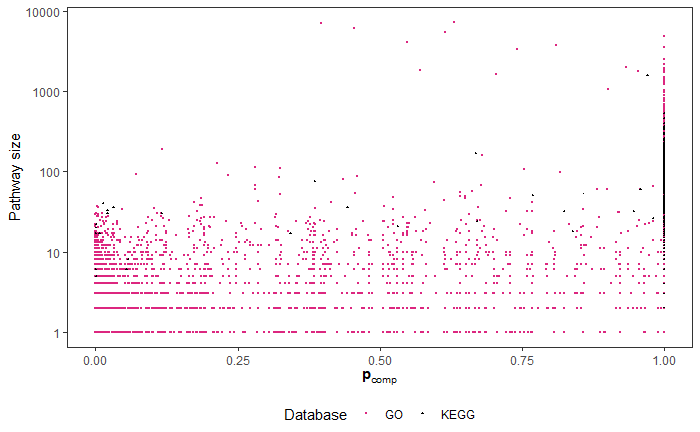

```r
library(ggplot2)

ggplot(results, aes(x = TDP_pvalue, y = size, color = Database, shape = Database)) +
  geom_point(size = 0.5) +
  scale_y_log10() +
  labs(x = expression(paste(bold("p")["comp"])), y = "Pathway size") +
  theme_test() +
  xlim(0, 1) +
  theme(legend.position = "bottom") +
  scale_shape_manual(values = c(GO = 16, KEGG = 17)) +
  scale_color_manual(values = c(
    "GO" = "#DC267F",
    "KEGG" = "#000000"
  ))
```

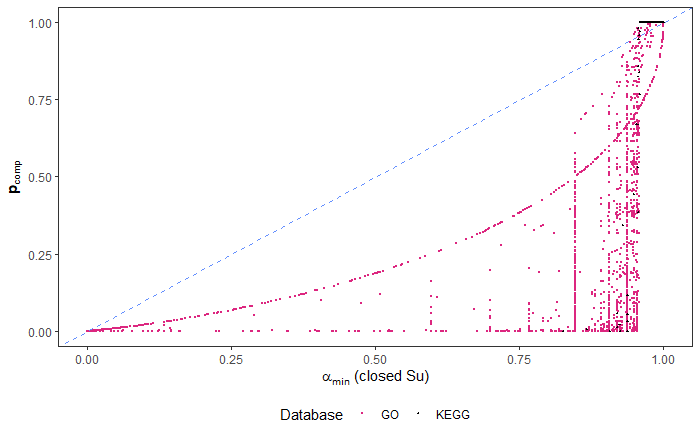

```r
ggplot(results, aes(x = min_alpha_Su, y = TDP_pvalue, color = Database, shape = Database)) +
  geom_point(size = 0.5) +
  geom_abline(intercept = 0, slope = 1, linetype = "dashed", color = "#648FFF") +
  labs(x = expression(paste(alpha["min"], " (closed Su)")),
       y = expression(paste(bold("p")["comp"]))) +
  theme_test() +
  xlim(0, 1) +
  ylim(0, 1) +
  theme(legend.position = "bottom") +
  scale_shape_manual(values = c(GO = 16, KEGG = 17)) +
  scale_color_manual(values = c(
    "GO" = "#DC267F",
    "KEGG" = "#000000"
  ))
```

**Note:** I used the $\texttt{grid_draw}$ and $\texttt{arrangeGrob}$ functions from the respective libraries $\texttt{grid}$ and $\texttt{gridExtra}$ to generate the plots in Figures 5 and 6. The code that I wrote for this is essentially the same to the code above, but it is very lengthy because you have to repeat the code above several times for each individual plot, hence why I decided to only demonstrate how to make singular plots. To obtain the plots for different methods, one can change the $\texttt{x}$ and $\texttt{y}$ parameters inside the $\texttt{ggplot}$ functions.

Finally, to create a plot similar to those shown in Appendix C, one can use the following code:

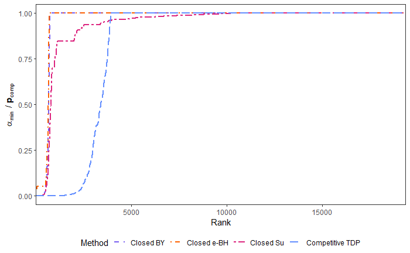

```r
sorted_long <- function(res, label) {
  ord <- order(res)
  data.frame(
    series = label,
    x      = seq_along(res),
    y      = res[ord],
    row.names = NULL
  )
}

df_long <- rbind(
  sorted_long(results$min_alpha_eBH, "min_alpha_eBH"),
  sorted_long(results$min_alpha_BY,  "min_alpha_BY"),
  sorted_long(results$min_alpha_Su,  "min_alpha_Su"),
  sorted_long(results$TDP_pvalue,    "TDP_pvalue")
)

colours <- c(min_alpha_eBH = "#FE6100", min_alpha_BY = "#785EF0",
             min_alpha_Su = "#DC267F",  TDP_pvalue = "#648FFF")
linetps <- c(min_alpha_eBH = "dotdash", min_alpha_BY = "dashed",
             min_alpha_Su = "twodash",  TDP_pvalue = "longdash")

ggplot(df_long, aes(x = x, y = y, color = series, linetype = series)) +
  geom_line(linewidth = 0.75) +
  labs(x = "Rank", y = expression(paste(alpha["min"], " / ", bold("p")["comp"])),
       color = "Method", linetype = "Method") +
  theme_test() +
  theme(legend.position = "bottom") +
  scale_x_continuous(expand = c(0, 0)) +
  scale_y_continuous(expand = c(0, 0.05)) +
  scale_color_manual(
    values = colours,
    breaks = c("min_alpha_BY", "min_alpha_eBH", "min_alpha_Su", "TDP_pvalue"),
    labels = c("Closed BY", "Closed e-BH", "Closed Su", "Competitive TDP")
  ) +
  scale_linetype_manual(
    values = linetps,
    breaks = c("min_alpha_BY", "min_alpha_eBH", "min_alpha_Su", "TDP_pvalue"),
    labels = c("Closed BY", "Closed e-BH", "Closed Su", "Competitive TDP")
  ) +
  guides(
    color = guide_legend(override.aes = list(linewidth = 1), position = "bottom"),
    linetype = guide_legend(position = "bottom")
  )
```